# Probability Distributions & Hypothesis Tests

```python
# Importing Libraries

import numpy as np
import pandas as pd
import scipy.stats as stats
import matplotlib.pyplot as plt
import seaborn as sns
```

5% of all DVD Players Manufactured by a large electronic company are found to be defective. A Quality Control Inspector selects 03 DVD Players. What is the Prob that Exactly One is Defective

```python
# Given
p = 0.05
x = 1
n = 3
```

```python
import scipy.stats as stats
```

```python
# Point Prob - exactly 1, exactly 2 - stats.binom.pmf()
# Probability Mass Function

stats.binom.pmf(x, n , p)

# P(X>2), P(X<=2):: stats.binom.cdf()
# Cumulative Density Function
```

```
0.135375
```

A LED bulb manufacturing company regularly conducts quality checks at specified periods on the products it manufactures. Historically, the failure rate for LED light bulbs that the company manufactures is 5%. Suppose a random sample of 10 LED light bulbs is selected. What is the probability that

- None of the LED bulbs are defective?
- Exactly one of the LED bulbs is defective?
- Two or fewer of the LED bulbs are defective?
- Three or more of the LED bulbs are defective

```python
p = 0.05
n = 10
# None of the LED bulbs are defective

print("The Prob of None Being Defective is ", stats.binom.pmf(0, n, p).round(4))
```

```
The Prob of None Being Defective is  0.5987
```

```python
# Exactly one of the LED bulbs is defective

print("The Prob of None Being Defective is ", stats.binom.pmf(1, n, p).round(4))
```

```
The Prob of None Being Defective is  0.3151
```

```python
# Two or fewer of the LED bulbs are defective

# P(0)+P(1)+P(2):: Cumulative Density Function ~ CDF in the end will give 1

stats.binom.cdf(2, n, p)
```

```
0.9884964426207031
```

```python
# Three or more of the LED bulbs are defective
1 - stats.binom.cdf(2, n, p)
```

```
0.01150355737929687
```

```python
# Prob Distribution Table
prob = []
CDF = []

for i in range(0, 11):
    prob.append(stats.binom.pmf(i, 10, 0.05).round(4))
    CDF.append(stats.binom.cdf(i, 10, 0.05).round(4))
```

```python
prob
```

```
[0.5987, 0.3151, 0.0746, 0.0105, 0.001, 0.0001, 0.0, 0.0, 0.0, 0.0, 0.0]
```

```python
import pandas as pd
```

```python
df = pd.DataFrame({"X":range(0,11), "P(X)": prob, "CDF":CDF})
```

```python
df
```

|  | X | P(X) | CDF |
| --- | --- | --- | --- |
| 0 | 0 | 0.5987 | 0.5987 |
| 1 | 1 | 0.3151 | 0.9139 |
| 2 | 2 | 0.0746 | 0.9885 |
| 3 | 3 | 0.0105 | 0.9990 |
| 4 | 4 | 0.0010 | 0.9999 |
| 5 | 5 | 0.0001 | 1.0000 |
| 6 | 6 | 0.0000 | 1.0000 |
| 7 | 7 | 0.0000 | 1.0000 |
| 8 | 8 | 0.0000 | 1.0000 |
| 9 | 9 | 0.0000 | 1.0000 |
| 10 | 10 | 0.0000 | 1.0000 |

Suppose a study performed at St. Jude’s Hospital shows that 30% of all patients arriving at the emergency room are subsequently admitted to the hospital for at least one night. Assuming that a sample of seven arrived at the emergency room each day:

- What is the probability that five or more in the sample of seven will require admittance to the hospital?
- What is the expected number of patients in the sample who will require admittance to the hospital?

```python
p = 0.30
n = 7
# probability that five or more 1 - P(0)+P(1)+P(2)+...P(4)

# exactly P(X=5)
# P(X is 5 or more)  = 1 - P(X<=4)

(1 - stats.binom.cdf(4, n, p)).round(4) # Prob of 5 or more
```

```
0.0288
```

```python
# What is the expected number of patients in the sample who will require admittance to the hospital
# Expected Value is Mean = Sum(X*P(X))
prob = []
CDF = []

for i in range(0, 100):
    prob.append(stats.binom.pmf(i, 100, p).round(4))
    CDF.append(stats.binom.cdf(i, 100, p).round(4))
```

```python
df = pd.DataFrame({"X":range(0, 100), "P(X)":prob, "CDF": CDF})
```

```python
df["X*P(X)"] = df["X"] * df["P(X)"]
```

```python
df
```

[output not shown]

```python
print("The Expected Value is ", df["X*P(X)"].sum()) # n*p => 7 * 0.30
```

[output not shown]

```python
df
```

[output not shown]

```python
# CDF Returns 1 in the end
# Sum of PMF Values will be equal to 1

df["P(X)"].sum() # This difference is because of Rounding of Values.
```

[output not shown]

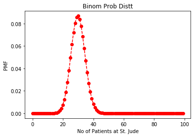

```python
# Plotting the PMF

import matplotlib.pyplot as plt

plt.plot(df["X"], df["P(X)"], "o--", c = 'r')
plt.xlabel("No of Patients at St. Jude")
plt.ylabel("PMF")
plt.title("Binom Prob Distt")
plt.show()
```

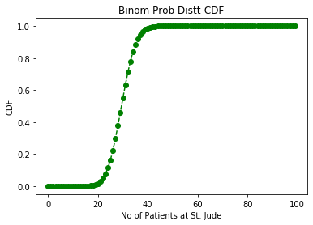

```python
plt.plot(df["X"], df["CDF"], "o--", c = 'g')
plt.xlabel("No of Patients at St. Jude")
plt.ylabel("CDF")
plt.title("Binom Prob Distt-CDF")
plt.show()
```

#### Summary of PMF and CDF

- Questions where it is asked exactly 5, exactly 2, P(X=2) ~ PMF
- PMF represents point probability.
- Questions use the words - atmost, atleast, more than , less than ~ cdf
- CDF represents sum of probabilities.

## Poisson Distribution

On an average, a household receives 9.5 telemarketing phone calls per week. Using Poisson, find the prob that randomly selected household receives exactly 06 calls.

```python
# import scipy.stats as stats

import math

((9.5**6)*(2.71828**-9.5))/math.factorial(6)
```

```
0.07642128438591989
```

```python
stats.poisson.pmf(6, 9.5) # x, lambda
```

```
0.07642079604012611
```

The Global Birth Rate and Death Rate is 4.3 per second & 1.8 per second respectively as per the US Census Bureau.

If we assume that the global birth and death rates follow the Poisson probability distribution, we can find the probability of any given number of global births or deaths for a given time interval.

- Find the probability of at most three global births during any given 1-second interval.
- Find the probability of exactly six global births using the Poisson formula.
- Find the probability of at most two global deaths

```python
# Find the probability of at most three global births during any given 1-second interval.
stats.poisson.cdf(3, 4.3) # x = 3, lambda = 4.3
```

```
0.3771539277296392
```

```python
# Find the probability of exactly six global births
stats.poisson.pmf(6, 4.3)
```

```
0.1191274827331984
```

```python
# Find the probability of at most two global deaths
stats.poisson.cdf(2, 1.8)
```

```
0.7306210859394124
```

Assuming that the weekly demand for the video recorder is a Poisson variable with mean 3, find the probability that the shop sells

- at least 3 in a week
- at most 7 in a week

```python
1 - stats.poisson.cdf(2, 3) # at least 3 in a week
```

```
0.5768099188731564
```

```python
stats.poisson.cdf(7, 3) # at most 7 in a week
```

```
0.9880954961436426
```

## Normal Distribution

According to a Sallie Mae survey and credit bureau data, in 2008, college students carried an average of $3173 debt on their credit cards (USA TODAY, April 13, 2009).

Suppose that current credit card debts for all college students have a normal distribution with a mean of 3173 and a standard deviation of 800.

Find the probability that credit card debt for a randomly selected college student is between $2109 and 3605.

```python
mu = 3173
sd = 800

zscore1 = (2109-mu)/sd # 2109
zscore2 = (3605-mu)/sd # 3605

print(zscore1, zscore2)
stats.norm.cdf(zscore2) - stats.norm.cdf(zscore1)
```

```
-1.33 0.54
```

```python
# Direct Approach - Does not involve the step of calc. Z Score.
stats.norm.cdf(3605, mu, sd)-stats.norm.cdf(2109, mu, sd)
```

```
0.6136423481340212
```

A survey on use of smart phones in India was conducted and it is observed the smart phone users spend 68 minutes in a day on average in sending messages and the corresponding standard deviation is 12 minutes. Assume that the time spent in sending messages follows a normal distribution.

- a) What proportion of the smart phone users are spending more than 90 minutes in sending messages daily?
- b) What proportion of customers are spending less than 20 minutes?
- c) What proportion of customers are spending between 50 minutes and 100 minutes?

```python
# pdf ~ kde in seaborn library
mu = 68
sd = 12

# Spending more than 90 minutes in sending messages daily

1 - stats.norm.cdf(90,mu,sd)
```

```
0.03337650758481725
```

```python
# What proportion of customers are spending less than 20 minutes
stats.norm.cdf((20-mu)/sd)
```

```
3.167124183311986e-05
```

```python
# What proportion of customers are spending between 50 minutes and 100 minutes
stats.norm.cdf(100, mu, sd) - stats.norm.cdf(50, mu, sd)
```

```
0.9293624181635521
```

Hupper Corporation produces many types of soft drinks, including Orange Cola. The filling machines are adjusted to pour 12 ounces of soda into each 12-ounce can of Orange Cola. However, the actual amount of soda poured into each can is not exactly 12 ounces; it varies from can to can. It has been observed that the net amount of soda in such a can has a normal distribution with a mean of 12 ounces and a standard deviation of .015 ounce.

## Sampling Error

population = [12,4,2,3,4,6,5,75,7,8,56,78,9,97,6,5,4,3,45,6,78,97,65,45,67,89,87,65,456,789,60, 98,7654,35678,909,8765,434,567,89,80]

sample = [1,23,45,67,89,87,43,2,3,4,56,7,8,9,6,5,4,3,45,6,78,97,65,45,67,89,87,65,456,789,6]

```python
population = [12,4,2,3,4,6,5,75,7,8,56,78,9,97,6,5,4,3,45,6,
              78,97,65,45,67,89,87,65,456,789,60, 98,7654,35678,909,8765,434,567,89,80]

sample = [1,23,45,67,89,87,43,2,3,4,56,7,8,9,6,5,4,3,45,
          6,78,97,65,45,67,89,87,65,456,789,6]
```

```python
# Sampling Error - Difference between the Pop Mean and the Sample Mean
np.mean(population) - np.mean(sample)

# Why Sampling Error Happens?
# It happens because of the random chance variation
```

```
1339.1427419354839
```

### Non Sampling Error -

- When the samples are not drawn at Random
- Tabulation error
- Error in Capturing Records.

```python
scores = [70, 78, 80, 80, 95]
```

```python
from itertools import combinations
```

```python
df = pd.DataFrame(list(combinations(scores, 3)))
```

```python
df["xbar"] = df.mean(axis =1).round(3)
```

```python
df.xbar.mean()
```

```
80.6
```

```python
np.mean(scores)
```

```
80.6
```

The mean wage per hour for all 5000 employees who work at a large company is 27.50, and the standard deviation is $3.70. Let x be the mean wage per hour for a random sample of certain employees selected from this company. Find the mean and standard deviation of x for a sample size of 30, 75 and 200

```python
# Mean of Samples is equal to Pop Mean

# Population mean (mew) is Mean of all the sample mean
# mew(xbar) = mew = 27.50

mew_xbar = 27.50

# Case 1 - n = 30
n = 30
sample_sd_xbar = 3.70/np.sqrt(30) # SD/sqrt(n)
print(mew_xbar)
print(sample_sd_xbar)

# As the Sample Size Increases, the SD of Samples decrease... at 200, it will be very less than n at 30.
```

```
27.5
0.6755244875897048
```

Assume that the weights of all packages of a certain brand of cookies are approximately normally distributed with a mean of 32 ounces and a standard deviation of .3 ounce.

Find the probability that the mean weight, x, of a random sample of 20 packages of this brand of cookies will be between 31.8 and 31.9 ounces.

```python
mew = 32
popsd = 0.3
n = 20

# Generally sd/root(n) is called Standard Error.
se = popsd/np.sqrt(n)

# Z score value for Xbar = (xbar - popmean)/se

stats.norm.cdf(31.9, mew, se) - stats.norm.cdf(31.8, mew, se)
```

```
0.06658400766103063
```

```python
se
```

```
0.06708203932499368
```

### Central Limit Theorem

- Acc to CLT, for any sample size, the sampling distribution of xbar is approximately normal irrespective of the shape of the pop. distributon.
- The mean and SD would be the same that we studied above mew_xbar = pop mean and SD(Sample) = popsd/root(n)
- For the shapes to be normal (if they are not normal), we need to consider the size of the data. Ideal size of the data should be 30 and above.
- So, if the data is 30 rows and above then we assume that the shape would be either normal or approximately normal.
- To test the same, we use Shapiro Wilk Test of Normality.
- The Same can be visualized using ProbPlot, KDEPLOT, ColumnGraphs, Histograms(tentative).

Q. According to a Sallie Mae survey and credit bureau data, in 2008, college students carried an average of 3173 debt on their credit cards (USA TODAY, April 13, 2009). Suppose that current credit card debts for all college students have a unknown distribution with a mean of 3173 and a standard deviation of 750. Let xbar be the mean credit card debt of a random sample of 400 students:

- What is the prob that the mean of the CC debt is within 70 of the pop mean.
- What is the prob that the mean of the CC debt is lower than pop mean by 50 or more.

```python
popmean = 3173
popsd = 750
n =400

se = popsd/np.sqrt(n)

# prob that the mean of the CC debt is within 70 of the pop mean

# (3173 - 70), 3173, (3173+70)  P(3103<=xbar<=3243)

stats.norm.cdf(3243, popmean, se)-stats.norm.cdf(3103, popmean, se)

# prob that the mean of the CC debt is lower than pop mean by 50 or more. (3173-50)::3123

stats.norm.cdf(3123, popmean, se)
```

```
0.09121121972586788
```

```python
stats.norm.ppf(0.95) # isf and ppf functions take prob value and return z value
```

```
1.6448536269514722
```

### T Distribution

DR. Moore wanted to estimate the mean cholesterol level for all the adults living in Bradford England. He took a sample of 25 men & found the mean cholesterol level is 186mg/dl with SD of 12 units. Construct the 95% CF Level Interval Estimate for Pop Mean.

```python
xbar = 186
s = 12
n = 25
se = s/np.sqrt(n)

# Z Critical - CF
stats.norm.interval(0.95, xbar, se)

# Direct approach to CI using t distribution
stats.t.interval(0.95, 24, xbar, se) # CF,df, xbar, se
```

```
(181.04664345209275, 190.95335654790725)
```

```python
# t critical
np.abs(stats.t.ppf((1-0.95)/2, 24)) # isf and ppf show the same value but with different sign
```

```
2.0638985616280205
```

Sixty four randomly selected adults who buy books for general reading were asked how much they usually spend on books per year.

This sample produced a mean of 1450 dollars and a standard deviation of 300 dollars for such annual expenses. Determine a 99% confidence interval for the corresponding population mean.

```python
xbar = 1450
s = 300
n = 64
se = s/np.sqrt(n)
df = n-1
stats.t.interval(0.99, df, xbar, se)
```

```
(1350.3945613839153, 1549.6054386160847)
```

### Applying Z Critical and T Critical to Find CIs on Data

```python
tips = sns.load_dataset("tips")
```

```python
tips.info()
```

```
<class 'pandas.core.frame.DataFrame'>
RangeIndex: 244 entries, 0 to 243
Data columns (total 7 columns):
total_bill    244 non-null float64
tip           244 non-null float64
sex           244 non-null category
smoker        244 non-null category
day           244 non-null category
time          244 non-null category
size          244 non-null int64
dtypes: category(4), float64(2), int64(1)
memory usage: 7.3 KB
```

```python
# Mean and SD of Total Bill Amount
print("The Mean of Total Bill is", tips.total_bill.mean())
print("The SD of Total Bill is", tips.total_bill.std()) # Denominator was n
```

```
The Mean of Total Bill is 19.785942622950824
The SD of Total Bill is 8.902411954856856
```

```python
# Draw a random sample of 30 rows of Data
sampledata = tips.sample(30)
```

```python
# Find Xbar and Standard Error
xbar = sampledata.total_bill.mean()
se = 8.90/np.sqrt(30) # Sigma_xbar

# Applying CI when the Pop SD is given to us.
stats.norm.interval(0.99, xbar, se)
```

```
(16.36584188561822, 24.736824781048444)
```

```python
# Pop Standard Deviation is not given to us.
# Sample Standard Deviation ~ t distribution

xbar = sampledata.total_bill.mean()
sample_sd = sampledata.total_bill.std(ddof = 1) # n-1:: ddof = 1 it means n-1

se = sample_sd/np.sqrt(30) # S_xbar

# Apply T distribution
stats.t.interval(0.99, 29, xbar, se)
```

```
(14.566617380954916, 26.536049285711748)
```

### Summary

- Z critical value is used when the Population Standard Deviation is available.
- t critical value is used when the Pop SD is not available. We only have access to the Sample Statistic.
- Sigma_Xbar is the Population Standard Deviation/Sqrt(n)
- s_xbar is the Sample Standard Deviation/Sqrt(n)
- Standard Deviation of t distribution is : sqrt[df/(df-2)]
- t distribution is a fair representation of true mean from the sample mean.

### Hypothesis Testing

A sample of 20 workers showed that it took, on average, 85 minutes for them to learn the food processing procedure on the new machine.

It is known that the learning times for all new workers are normally distributed with a population standard deviation of 7 minutes.

### Step 01: Define the Null Hypothesis and Alternate Hypothesis

- Ho: mew = 90
- H1: mew !=90

### Step 03: Find the Critical Value

```python
### Critical Value
zcrit = stats.norm.isf(0.975).round(3) # 0.025
```

### Step 04: Calculate the test statistic

```python
# Test Statistic
xbar = 85
n = 20
popsd = 7
mew = 90
zteststats = (xbar-mew)/(popsd/np.sqrt(n))
```

```python
print(zteststats, zcrit)
```

```
-3.1943828249996997 -1.96
```

### Average IQ Example

- n = 75
- mew = 100
- xbar = 105
- popsd = 15
- Check if the Average IQ has changed - Two Tail Test at 0.95
- Z Critical Value - 1.96

```python
(105-100)/(15/np.sqrt(75))
```

```
2.886751345948129
```

### Conclusion

Since the Test Statistic value is more than the Critical Value, We reject the Ho. It means that the Average IQ has changed.

## Hypothesis Testing ~ A Summary

- Sampling ~ Confidence Intervals
- Hypothesis Testing ~ Claim, Opinion about Data and You wanna test that claim.
- Hyp Testing involves testing of claims that can help make inferences about the Population.
- Hypothesis Testing involves two Hypothesis - Null & Alternate
- There are two ways to conclude the Results of the Tests - Critical Value vs Test Statistic.
- Another one is comparing P Value with Alpha. For e.g. p value comes out to be 0.12 and alpha defined is 0.05. It is similar to comparing critical value with Test Statistic.
- There are 04 types of tests: Z Test, T-Test, Anova & Chi Square Tests.
- Numerical Values - T-Test or Z Test (Discl: PopSD need to be there for a Z test to be applied)
- For e.g. In Titanic Dataset, If the Avg Age of the Passenger and The Avg Fare Paid has some Relation - TTest.
- In the Same Dataset, Survival of the Passenger is dependent on the Age (Survived - 0 & 1, Age - Num):: Cat Vs Numerical Variable - Anova.
- Categories Vs Categories - CHI SQUARE TEST:: Non Parametric Test.
- For e.g. in titanic, if the Survival of the Passenger is dependent on the PClass (1,2,3)

### T Test

- Sample value is <=30.
- When the Population Standard Deviation is not given. Then We will be using T test.
- Test Statistic = (Xbar - Pop Mean)/(Sample SD/root(n))
- **Rule of P Value - If the PValue is Less than 0.05, then we reject the Ho. However, if the P Value is 0.05 or more than 0.05, then we *Fail to Reject the Ho***

### T Test

A Lorry manufacturer claims that the average annual maintenance cost for its vehicles is 500 dollars. Maintenance department of one of the customers believes it to be higher, and to test the assumption, they randomly pull a sample of six lorries from their large fleet. From this normally distt. sample, the mean annual maintenance cost was found to be 555 dollars with a SD of 75 dollars. At 0.05, find if the manufacturer's claim is valid.

### Step 01: Define Null & Alternate Hypothesis

- $H_0$: $\mu$ = 500
- $H_1$: $\mu$ > 500

### Step 02: Define the Level of Significance or Alpha

- Alpha = 0.05 (T Table)

### Step 03: Calculate the Critical Value - 2.015

By Looking at the T table https://www.stat.tamu.edu/~lzhou/stat302/T-Table.pdf, we need two parameters - Degrees of Freedom (n-1) and Alpha Value and thus we calculate the $T Crit$

### Step 04: Calculate the Test Statistic

```python
# Test Statistic
xbar = 555
popmean = 500
se = 75/np.sqrt(6)

teststats = (xbar-popmean)/se
print(teststats)
```

```
1.7962924780409972
```

```python
# Calc the P Value
# Remember that in Python, the Manual PValue Calc is One Sided. Thus, we need to multiply by 2
1 - stats.t.cdf(teststats, 5)

# Since P Value > 0.05, then we Fail to Reject the Claim.
```

```
0.06619400268915654
```

### Step 05: Draw Conclusion

Since the Test Statistic < Crit, thus we can say that we fail to reject the Ho meaning that the Average Maintenance Cost is 500 Dollars.

### Understanding P Value

John was testing Ho: mu =0 against H1 mu!=0 against a sample of 06 observations. His Test Statistic comes out to be t = 2.75. Find the P Value and Conclude the Test.

- If PValue < Alpha (0.05) => Reject the Ho else Fail to Reject the Ho

```python
# Pr(value > t=2.75)
print("The Pvalue is ", (1 - stats.t.cdf(2.75, 5))*2)
```

```
The Pvalue is  0.040310222540025364
```

## One Sample T Test - Sample and Pop Mean is Given

### Internet Mobile Time Case Study

Experience marketing Services reported that the typical American spend a mean of 144 minutes(2.4 hours) per day accessing the internet via mobile device. In order to test the validity of the statement, you select a sample of 30 friends and family. The result for the time spent per day accessing the Internet via mobile device (in minutes) are stored.

Is there enough evidence that Pop Mean Time spent Per Day accessing the internet via mobile device is different from 144 minutes.

### Step 01: Define Null & Alternate Hypothesis

- $H_0$: $\mu$ = 144
- $H_1$: $\mu$ != 144

### Step 02: Define the Level of Significance or Alpha

- Alpha = 0.05 (T Table)

### Step 04: Calculate the Test Statistic & P Value

```python
mins = [72,144,48,72,36,360,44,30,432,24,288,144,144,240,432,144,
        144,144,576,216,72,72,144,288,144,36,288,48,288,144]
```

```python
# One Sample T Test
xbar = np.mean(mins) # Sample Mean
se = stats.sem(mins) # np.std(mins, ddof = 1)/np.sqrt(30)
mew = 144
freedom = len(mins) - 1 # Degrees of Freedom: n-1
alpha = 0.05
print("Degrees of Freedom", freedom)
print("Standard Error ", se)

# Test Statistic and PValue
teststats, pvalue = stats.ttest_1samp(mins, mew) # Sample Data, Pop Mean Parameter
print("The Test Statistic is ", teststats)
print("The PValue is ", pvalue)

# Conclusion

if(pvalue>alpha):
    print("Fail to Reject the Ho")
else:
    print("Reject the Ho meaning that the Mean Value is Different from the Hypothesized Mean")
```

```
Degrees of Freedom 29
Standard Error  25.53059617392764
The Test Statistic is  1.2246743653638934
The PValue is  0.23055326882983757
Fail to Reject the Ho
```